# Mastering Product Analytics - Final Assignment

Bence L. Toth (166504)

June 6th, 2019

This analysis is based on the concepts of the book Lean Analytics: Use Data Analytics to Build a Better Startup Faster by Alistair Croll and Benjamin Yoskovitz. It aims to carry out a simple data exploration regarding the topics of Acquisition, Activity and Retention, three key lifecycle stages of a product, according to the book.

```r
rm(list = ls())
options(digits = 3)
options(scipen = 999)
library(dplyr)
library(tidyr)
library(ggplot2)
library(fpp2)
library(DataCombine)
library(data.table)
library(kableExtra)
library(ggthemes)
custom_theme <- theme_tufte() +
  theme(legend.position = c(0.9, 0.9),
        legend.title = element_text(face = "italic", size = 12),
        axis.title = element_text(face = "bold", size = 14))
```

## About the data

```r
data <- fread('data/activity.csv')
```

The example is based on a real Software as a Service, subscription based product. There are two datasets available:

- *registrations.csv*: unique users with basic demographics
- *activity.csv*: which users have been active in which month

More information about the datasets can be accessed on the project’s [GitHub repository](https://github.com/BenceToth/ceu_product-analytics).

## Acquisition

*“Acquisition is a stage where you should generate attention through a variety of means, both organic and inorganic. Relevant metrics to assess acquisition include traffic, mentions, cost per click, search results, cost of acquisition, open rate etc.”*

As a first step in the analysis, let’s see the number of registrations in each month:

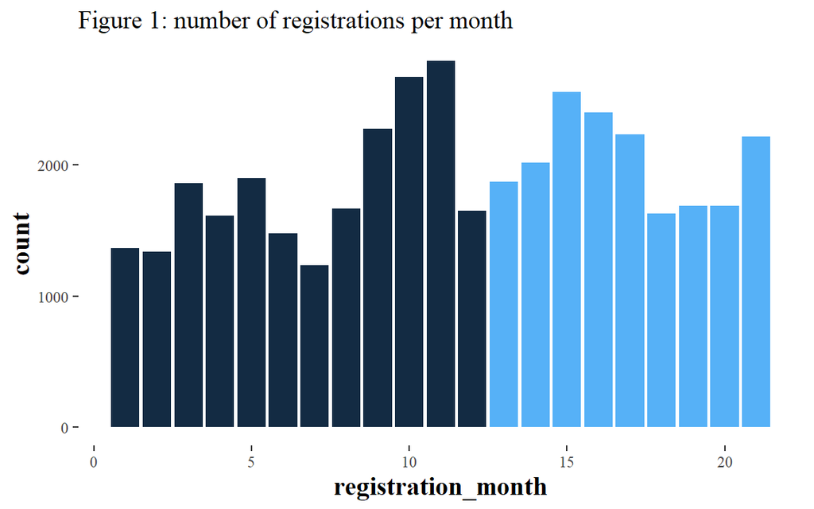

```r
data %>%
  group_by(registration_month) %>%
  summarize(count = n_distinct(id)) %>%
  ggplot(aes(x = registration_month, y = count, fill = ifelse(registration_month <= 12, 1, 2))) +
  geom_col(show.legend = FALSE) +
  ggtitle('Figure 1: number of registrations per month') +
  custom_theme
```

To dig deeper into the data, we can see the year-over-year growth of registrations:

```r
# add year and month
data <- data %>%
  mutate(year = ifelse(registration_month <= 12, 1, 2),
         reg_month = ifelse(registration_month <= 12, registration_month, registration_month - 12))

# summarize registration number by year and month
yoyg <- data %>%
  select(id, year, reg_month) %>%
  group_by(reg_month, year) %>%
  summarize(n_distinct(id)) %>%
  rename(regs = 'n_distinct(id)') %>%
  # get year-over-year growth
  spread(year, regs) %>%
  rename(year_1 = '1',
         year_2 = '2') %>%
  mutate(yoyg = year_2 / year_1) %>%
  select(reg_month, yoyg) %>%
  filter(reg_month <= 10)

yoyg$reg_month <- as.factor(yoyg$reg_month)

kable(yoyg, caption = 'Table 1: Year on Year Growth of registrations') %>%
  kable_styling('striped', full_width = F, position = 'center') %>%
  row_spec(0, color = 'white', background = 'blue', align ='c')
```

Table 1: Year on Year Growth of registrations

| reg_month | yoyg |
| --- | --- |
| 1 | 1.373 |
| 2 | 1.505 |
| 3 | 1.373 |
| 4 | 1.491 |
| 5 | 1.175 |
| 6 | 1.105 |
| 7 | 1.365 |
| 8 | 1.014 |
| 9 | 0.976 |
| 10 | NA |

The next plot shows the growth rates for each month, together with the Naive forecast of Month 22 (October of the second year):

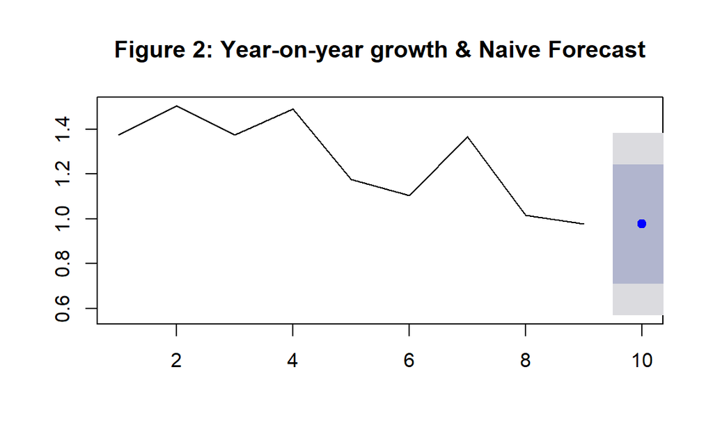

```r
ts <- ts(data = yoyg$yoyg, frequency = 1, start = 1, end = 9)
fc <- naive(ts, h = 1)

plot(fc, main = 'Figure 2: Year-on-year growth & Naive Forecast')
```

The year-over-year data seems to be decreasing, but keeping higher number of registrations in year 2 up until September. The Naive forecast for October is 0.976.

We can investigate if there are any differences in registration numbers based on geographic regions:

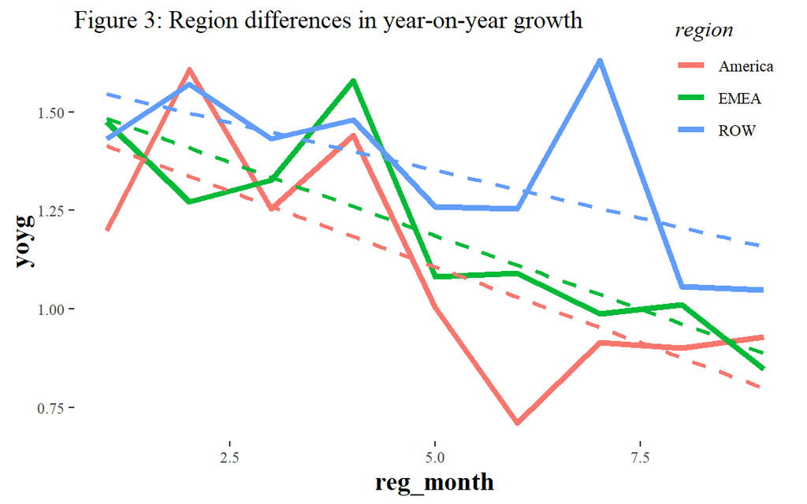

```r
regions <- data %>%
  select(id, year, reg_month, region) %>%
  group_by(region, reg_month, year) %>%
  summarize(n_distinct(id)) %>%
  rename(regs = 'n_distinct(id)') %>%
  # get year-over-year growth
  spread(year, regs) %>%
  rename(year_1 = '1',
         year_2 = '2') %>%
  mutate(yoyg = year_2 / year_1) %>%
  select(region, reg_month, yoyg) %>%
  filter(reg_month < 10)

ggplot(data = regions, aes(x = reg_month, y = yoyg, col = region)) +
  geom_line(size = 1.5) +
  ggtitle('Figure 3: Region differences in year-on-year growth') +
  geom_smooth(method = 'lm', se = FALSE, linetype = 'dashed') +
  custom_theme
```

Comparing the regions, there seems to be a difference. *America* underperforms both *EMEA* and the rest of the world, except in the beginning of year 1. All show a decreasing trend in registration numbers, but the *ROW* region seems to produce the highest growth. It is likely to drive future growth in registrations, while *EMEA*, and especially *America* might have different interest in the product, or they were less affected by the marketing campaigns.

## Activity

*“Activation is turning the resulting drive-by visitors into users who are somehow enrolled. It can be done by tracking a specific activity milestone, such as enrollments, signups, completed onboarding process, used the service at least once, subscriptions etc.”*

The plot below shows the number of active users in each month:

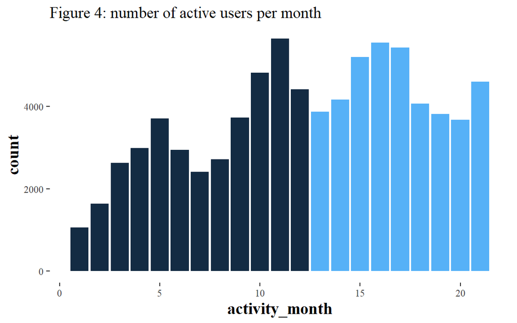

```r
data %>%
  group_by(activity_month) %>%
  summarize(count = n()) %>%
  ggplot(aes(x = activity_month, y = count, fill = ifelse(activity_month <= 12, 1, 2))) +
  geom_col(show.legend = FALSE) +
  ggtitle('Figure 4: number of active users per month') +
  custom_theme
```

As we seen, the region of *America* struggles with new registrations. Let’s see the percentage of *America* among active users in each month:

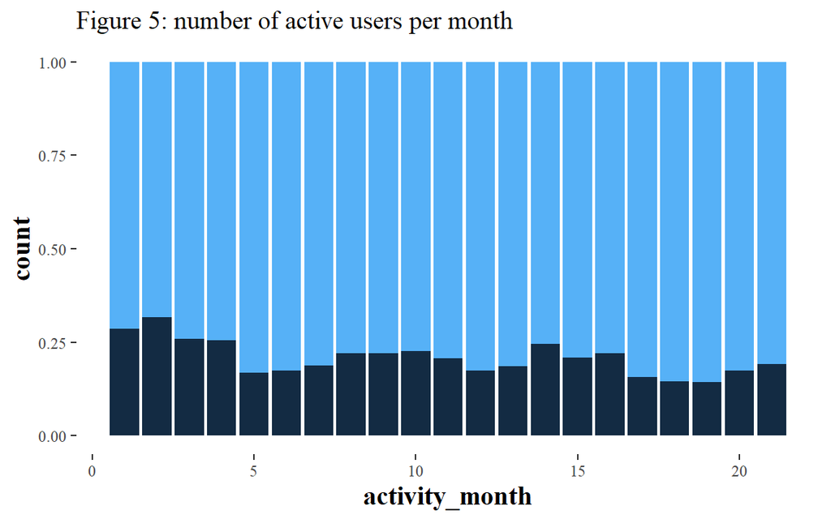

```r
data %>%
  group_by(region, activity_month) %>%
  summarize(count = n()) %>%
  ggplot(aes(x = activity_month, y = count, fill = ifelse(region == 'America', 1, 2))) +
  geom_bar(position = 'fill', stat = 'identity', show.legend = FALSE) +
  ggtitle('Figure 5: number of active users per month') +
  custom_theme
```

We can see that the number of users from *America* is on average between 17-22%. The company has to think about investing in other ways to drive that market, or focus on the rest of their clients which seem to have better registration and activity rates.

It is worth it to also take a look at the users’ activity patterns. The users can be classified as *New* (registered that month), *Retained* (was active the previous month as well) or *Resurrected* (was inactive the previous month and not *New*).

```r
data_slide <- slide(data = data, Var = 'activity_month', TimeVar = 'activity_month',
                             GroupVar = 'id', NewVar = 'prev_activity', slideBy = -1,
                             keepInvalid = FALSE, reminder = TRUE)

data_slide <- data_slide %>%
  mutate(class = ifelse(activity_month == registration_month, 'New', ifelse(activity_month - 1 != prev_activity | is.na(prev_activity), 'Resurrected', 'Retained')))
```

To illustrate this, take a look at a randomly chosen user’s activity history:

```r
data_slide %>%
  filter(id == 'id_30809') %>%
  select(id, activity_month, registration_month, class) %>%
  kable(caption = 'Table 2: User activity history') %>%
  kable_styling('striped', full_width = F, position = 'center') %>%
  row_spec(0, color = 'white', background = 'blue', align ='c')
```

Table 2: User activity history

| id | activity_month | registration_month | class |
| --- | --- | --- | --- |
| id_30809 | 7 | 7 | New |
| id_30809 | 8 | 7 | Retained |
| id_30809 | 10 | 7 | Resurrected |
| id_30809 | 11 | 7 | Retained |
| id_30809 | 12 | 7 | Retained |

Let’s now look at the number of *Retained* active users in each month:

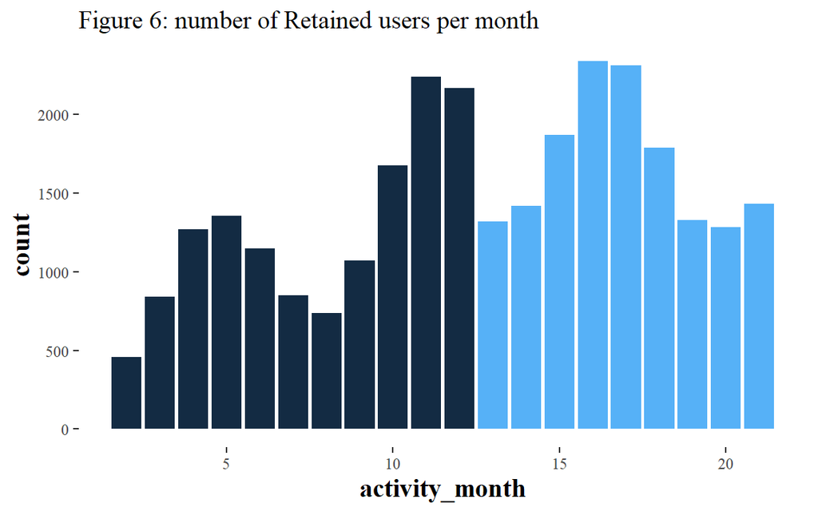

```r
data_slide %>%
  filter(class == 'Retained') %>%
  group_by(activity_month) %>%
  summarize(count = n()) %>%
  ggplot(aes(x = activity_month, y = count, fill = ifelse(activity_month <= 12, 1, 2))) +
  geom_col(show.legend = FALSE) +
  ggtitle('Figure 6: number of Retained users per month') +
  custom_theme
```

## Retention

The main task during the Retention phase is to *“convince users to come back repeatedly, exhibiting sticky behavior. It can be tracked by metrics such as engagement, time since last visit, daily and monthly active use, churns etc.”*

In the case of our example, we can calculate the second month retention rate (registered users in Month 1 who have been active in Month 2).

```r
registered_month_1 <- data %>%
  filter(registration_month == 1) %>%
  summarize(count = n_distinct(id))

activity_month_2 <- data %>%
  filter(registration_month == 1 & activity_month == 2) %>%
  summarize(count = n())

retention_rate_1_2 <- paste0(round(activity_month_2[[1]] / registered_month_1[[1]], 4) * 100, '%')
```

The second month retention rate is 46.33%. It can be considered pretty good, it usually ranges from 20% to 60%.

Let’s see the same metric for year two (between Month 13 and 14).

```r
registered_month_13 <- data %>%
  filter(registration_month == 13) %>%
  summarize(count = n_distinct(id))

activity_month_14 <- data %>%
  filter(registration_month == 13 & activity_month == 14) %>%
  summarize(count = n())

retention_rate_13_14 <- paste0(round(activity_month_14[[1]] / registered_month_13[[1]], 4) * 100, '%')
```

36.84% of users who registered in January, second year were active in February. It is still an acceptable value, but what could be behind the 10% drop since last year? It can be because the majority of users who are interested in the product have already signed up, so the pool of potential interested users for new registrations became smaller. This way, the users who joined in the second year were not that engaged in the product and decided to opt out of it in the upcoming month with a higher percentage.

We can also calculate the second month retention rate based on the operating systems of the users:

```r
opsys_month_1 <- data %>%
  filter(registration_month == 1) %>%
  group_by(operating_system) %>%
  summarize(reg_count = n_distinct(id))

opsys_month_2 <- data %>%
  filter(registration_month == 1 & activity_month == 2) %>%
  group_by(operating_system) %>%
  summarize(active_count = n())

opsys_retention_rate <- left_join(opsys_month_1, opsys_month_2, by = 'operating_system') %>%
  mutate(opsys_retention = round(active_count / reg_count, 4) * 100)

kable(opsys_retention_rate, caption = 'Table 3: Second month retention rate by Operating System') %>%
  kable_styling('striped', full_width = F, position = 'center') %>%
  row_spec(0, color = 'white', background = 'blue', align ='c')
```

Table 3: Second month retention rate by Operating System

| operating_system | reg_count | active_count | opsys_retention |
| --- | --- | --- | --- |
| Linux | 12 | 5 | 41.7 |
| Mac | 161 | 99 | 61.5 |
| Unknown | 537 | 204 | 38.0 |
| Windows | 654 | 324 | 49.5 |

## Conclusion

With this basic introduction to different product analytics practices, we could see how little effort and some programming knowledge could lead to interesting hypotheses about user behavior. Methods such as A/B testing could be applied to test these hypotheses, for example: how optimizing the Linux version of the product will influence retention rates, which regions should be targeted with specific advertising campaigns etc.

This project was done as a requirement for the Mastering Product Analytics course at Central European University in Hungary. The R code along with the dataset can be found my ceu_product-analytics repository on GitHub.